# Ayudantía 3 Análisis de Regresión

## Parte 1: Regresión Lineal Simple

Consideremos los datos provistos en una encuesta donde se pregunto cuantos ml de vino bebió en el almuerzo y la duración de la siesta que tomó después. Los datos a utilizar: `siesta.csv`

```r
siesta <- readr::read_csv("siesta.csv")
head(siesta,4)
```

```
## # A tibble: 4 x 2
##    wine sleep
##   <dbl> <dbl>
## 1  352.  52.0
## 2  439.  52.1
## 3  367.  44.2
## 4  268.  36.8
```

## Parte 2: Regresión Lineal Múltiple

Usaremos los datos `Fish market` extraidos de [kaggle](https://www.kaggle.com/aungpyaeap/fish-market) .

- Specie : species name of fish.
- Weight : weight of fish in Gram g.
- Length1 : vertical length in cm.
- Length2 : diagonal length in cm.
- Length3 : cross length in cm .
- Height : height in cm.
- Widht : diagonal width in cm.

```r
datafish <- readr::read_csv("Fish.csv")
head(datafish,4)
```

```
## # A tibble: 4 x 7
##   Species Weight Length1 Length2 Length3 Height Width
##   <chr>    <dbl>   <dbl>   <dbl>   <dbl>  <dbl> <dbl>
## 1 Bream      242    23.2    25.4    30     11.5  4.02
## 2 Bream      290    24      26.3    31.2   12.5  4.31
## 3 Bream      340    23.9    26.5    31.1   12.4  4.70
## 4 Bream      363    26.3    29      33.5   12.7  4.46
```

#### Actividad:

1. Realice un análisis exploratorio de las variables. Calcule la correlación y dispersión de la variable `Weight` con el resto de las variables. Comente.

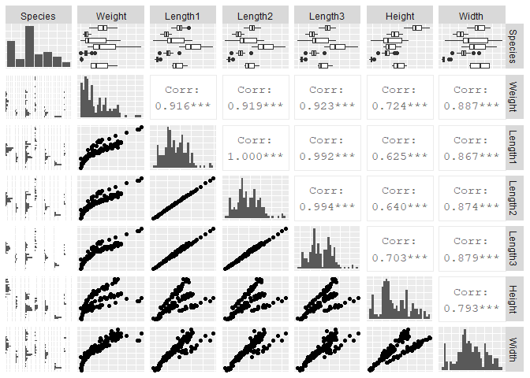

```r
GGally::ggpairs(datafish,
                diag = list(continuous = "barDiag"),
                axisLabels = "none")
```

2. Ajuste un modelo de regresión lineal solo con las variables cuantitativas. Comente la variabilidad explicada e interprete los coeficientes estimados de las variables.

```r
#str(datafish)
mod1 <- lm(Weight ~ . , data= datafish[-1])
summary(mod1)
```

```
##
## Call:
## lm(formula = Weight ~ ., data = datafish[-1])
##
## Residuals:
##     Min      1Q  Median      3Q     Max
## -243.69  -65.10  -25.52   57.98  447.25
##
## Coefficients:
##             Estimate Std. Error t value Pr(>|t|)
## (Intercept) -499.587     29.572 -16.894  < 2e-16 ***
## Length1       62.355     40.209   1.551  0.12302
## Length2       -6.527     41.759  -0.156  0.87601
## Length3      -29.026     17.353  -1.673  0.09643 .
## Height        28.297      8.729   3.242  0.00146 **
## Width         22.473     20.372   1.103  0.27169
## ---
## Signif. codes:  0 '***' 0.001 '**' 0.01 '*' 0.05 '.' 0.1 ' ' 1
##
## Residual standard error: 123.2 on 153 degrees of freedom
## Multiple R-squared:  0.8853, Adjusted R-squared:  0.8815
## F-statistic: 236.2 on 5 and 153 DF,  p-value: < 2.2e-16
```

```r
mod2 <- lm(Weight ~ . , data= datafish[-c(1,4)])
summary(mod2)
```

```
##
## Call:
## lm(formula = Weight ~ ., data = datafish[-c(1, 4)])
##
## Residuals:
##     Min      1Q  Median      3Q     Max
## -242.89  -65.84  -24.36   57.61  446.05
##
## Coefficients:
##             Estimate Std. Error t value Pr(>|t|)
## (Intercept) -500.131     29.274 -17.085  < 2e-16 ***
## Length1       56.738     17.969   3.157  0.00192 **
## Length3      -30.130     15.799  -1.907  0.05837 .
## Height        28.455      8.643   3.292  0.00123 **
## Width         21.476     19.286   1.114  0.26720
## ---
## Signif. codes:  0 '***' 0.001 '**' 0.01 '*' 0.05 '.' 0.1 ' ' 1
##
## Residual standard error: 122.8 on 154 degrees of freedom
## Multiple R-squared:  0.8853, Adjusted R-squared:  0.8823
## F-statistic: 297.1 on 4 and 154 DF,  p-value: < 2.2e-16
```

```r
mod3 <- lm(Weight ~ . , data= datafish[-c(1,4,7)])
summary(mod3)
```

```
##
## Call:
## lm(formula = Weight ~ ., data = datafish[-c(1, 4, 7)])
##
## Residuals:
##     Min      1Q  Median      3Q     Max
## -265.92  -64.14  -19.90   55.73  428.29
##
## Coefficients:
##             Estimate Std. Error t value Pr(>|t|)
## (Intercept) -491.467     28.243 -17.402  < 2e-16 ***
## Length1       70.327     13.200   5.328 3.44e-07 ***
## Length3      -40.938     12.477  -3.281  0.00128 **
## Height        35.923      5.457   6.583 6.75e-10 ***
## ---
## Signif. codes:  0 '***' 0.001 '**' 0.01 '*' 0.05 '.' 0.1 ' ' 1
##
## Residual standard error: 122.9 on 155 degrees of freedom
## Multiple R-squared:  0.8843, Adjusted R-squared:  0.8821
## F-statistic: 395.1 on 3 and 155 DF,  p-value: < 2.2e-16
```

3. Ajuste un modelo de regresión lineal con la metodología *forward*. Comente.

```r
modelof <-  step(lm(Weight ~ 1 , data = datafish[-1]),scope = ~ Length1 + Length2 + Length3 + Height + Width,
                direction = "forward" )
```

```
## Start:  AIC=1870.99
## Weight ~ 1
##
##           Df Sum of Sq      RSS    AIC
## + Length3  1  17251026  2996433 1569.2
## + Length2  1  17085990  3161469 1577.7
## + Length1  1  16978060  3269399 1583.1
## + Width    1  15912356  4335103 1627.9
## + Height   1  10623359  9624100 1754.7
## <none>                 20247459 1871.0
##
## Step:  AIC=1569.2
## Weight ~ Length3
##
##           Df Sum of Sq     RSS    AIC
## + Width    1    507023 2489410 1541.7
## + Height   1    225843 2770591 1558.7
## <none>                 2996433 1569.2
## + Length2  1      1783 2994650 1571.1
## + Length1  1         1 2996433 1571.2
##
## Step:  AIC=1541.73
## Weight ~ Length3 + Width
##
##           Df Sum of Sq     RSS    AIC
## <none>                 2489410 1541.7
## + Height   1   15996.7 2473414 1542.7
## + Length1  1    2902.9 2486507 1543.5
## + Length2  1    1550.4 2487860 1543.6
```

```r
summary(modelof)
```

```
##
## Call:
## lm(formula = Weight ~ Length3 + Width, data = datafish[-1])
##
## Residuals:
##     Min      1Q  Median      3Q     Max
## -258.84  -77.17  -25.78   81.79  441.57
##
## Coefficients:
##             Estimate Std. Error t value Pr(>|t|)
## (Intercept) -520.939     29.332 -17.760  < 2e-16 ***
## Length3       19.487      1.812  10.755  < 2e-16 ***
## Width         70.343     12.479   5.637 7.91e-08 ***
## ---
## Signif. codes:  0 '***' 0.001 '**' 0.01 '*' 0.05 '.' 0.1 ' ' 1
##
## Residual standard error: 126.3 on 156 degrees of freedom
## Multiple R-squared:  0.8771, Adjusted R-squared:  0.8755
## F-statistic: 556.4 on 2 and 156 DF,  p-value: < 2.2e-16
```

4. Ajuste un modelo de regresión lineal con la metodología *backward*. Comente.

```r
modstep1 <- step(lm(Weight  ~ .,data = datafish[-1]),direction = "backward")
```

```
## Start:  AIC=1536.7
## Weight ~ Length1 + Length2 + Length3 + Height + Width
##
##           Df Sum of Sq     RSS    AIC
## - Length2  1       371 2323024 1534.7
## - Width    1     18474 2341127 1536.0
## <none>                 2322653 1536.7
## - Length1  1     36509 2359162 1537.2
## - Length3  1     42474 2365127 1537.6
## - Height   1    159527 2482179 1545.3
##
## Step:  AIC=1534.73
## Weight ~ Length1 + Length3 + Height + Width
##
##           Df Sum of Sq     RSS    AIC
## - Width    1     18706 2341729 1534.0
## <none>                 2323024 1534.7
## - Length3  1     54862 2377885 1536.4
## - Length1  1    150390 2473414 1542.7
## - Height   1    163484 2486507 1543.5
##
## Step:  AIC=1534
## Weight ~ Length1 + Length3 + Height
##
##           Df Sum of Sq     RSS    AIC
## <none>                 2341729 1534.0
## - Length3  1    162644 2504373 1542.7
## - Length1  1    428862 2770591 1558.7
## - Height   1    654703 2996433 1571.2
```

```r
summary(modstep1)
```

```
##
## Call:
## lm(formula = Weight ~ Length1 + Length3 + Height, data = datafish[-1])
##
## Residuals:
##     Min      1Q  Median      3Q     Max
## -265.92  -64.14  -19.90   55.73  428.29
##
## Coefficients:
##             Estimate Std. Error t value Pr(>|t|)
## (Intercept) -491.467     28.243 -17.402  < 2e-16 ***
## Length1       70.327     13.200   5.328 3.44e-07 ***
## Length3      -40.938     12.477  -3.281  0.00128 **
## Height        35.923      5.457   6.583 6.75e-10 ***
## ---
## Signif. codes:  0 '***' 0.001 '**' 0.01 '*' 0.05 '.' 0.1 ' ' 1
##
## Residual standard error: 122.9 on 155 degrees of freedom
## Multiple R-squared:  0.8843, Adjusted R-squared:  0.8821
## F-statistic: 395.1 on 3 and 155 DF,  p-value: < 2.2e-16
```

```r
modboth <- step(lm(Weight ~ ., data=datafish[-1]),
                direction = "both")
```

```
## Start:  AIC=1536.7
## Weight ~ Length1 + Length2 + Length3 + Height + Width
##
##           Df Sum of Sq     RSS    AIC
## - Length2  1       371 2323024 1534.7
## - Width    1     18474 2341127 1536.0
## <none>                 2322653 1536.7
## - Length1  1     36509 2359162 1537.2
## - Length3  1     42474 2365127 1537.6
## - Height   1    159527 2482179 1545.3
##
## Step:  AIC=1534.73
## Weight ~ Length1 + Length3 + Height + Width
##
##           Df Sum of Sq     RSS    AIC
## - Width    1     18706 2341729 1534.0
## <none>                 2323024 1534.7
## - Length3  1     54862 2377885 1536.4
## + Length2  1       371 2322653 1536.7
## - Length1  1    150390 2473414 1542.7
## - Height   1    163484 2486507 1543.5
##
## Step:  AIC=1534
## Weight ~ Length1 + Length3 + Height
##
##           Df Sum of Sq     RSS    AIC
## <none>                 2341729 1534.0
## + Width    1     18706 2323024 1534.7
## + Length2  1       602 2341127 1536.0
## - Length3  1    162644 2504373 1542.7
## - Length1  1    428862 2770591 1558.7
## - Height   1    654703 2996433 1571.2
```

```r
summary(modboth)
```

```
##
## Call:
## lm(formula = Weight ~ Length1 + Length3 + Height, data = datafish[-1])
##
## Residuals:
##     Min      1Q  Median      3Q     Max
## -265.92  -64.14  -19.90   55.73  428.29
##
## Coefficients:
##             Estimate Std. Error t value Pr(>|t|)
## (Intercept) -491.467     28.243 -17.402  < 2e-16 ***
## Length1       70.327     13.200   5.328 3.44e-07 ***
## Length3      -40.938     12.477  -3.281  0.00128 **
## Height        35.923      5.457   6.583 6.75e-10 ***
## ---
## Signif. codes:  0 '***' 0.001 '**' 0.01 '*' 0.05 '.' 0.1 ' ' 1
##
## Residual standard error: 122.9 on 155 degrees of freedom
## Multiple R-squared:  0.8843, Adjusted R-squared:  0.8821
## F-statistic: 395.1 on 3 and 155 DF,  p-value: < 2.2e-16
```

5. ¿Cuál de los modelos anteriores elegiría?